# Ejercicio 1 — Monte Carlo e Importance Sampling

## Máster Executive en Finanzas Cuantitativas 2026 — AFI Global Education

### Fundamentos Matemáticos: Probabilidad y Simulación

### Enunciado

Queremos estimar la integral

$$I = \int_0^1 g(x)\, dx = \int_0^1 \cos\!\left(\frac{\pi x}{2}\right) dx.$$

### Hoja de ruta de la resolución

| Apartado | Qué se pide | Herramienta |
| --- | --- | --- |
| **1.0** | Expresar $I$ como esperanza $\mathbb{E}[\,\cdot\,]$ | Definición de esperanza |
| **1.1** | Hallar $\lambda$ para que $\tilde f(x)=\lambda(1-x^2)$ sea densidad | Condición de normalización |
| **1.2** | Calcular $I$: (a) analítico, (b) Monte Carlo directo, (c) *importance sampling* | Integración + simulación + Cardano |
| **1.3** | Comparar la varianza de ambos estimadores Monte Carlo | Varianza del estimador |

**Idea global.** Una integral sobre $(0,1)$ puede leerse como el valor esperado de una función de una variable aleatoria. Esto permite *estimarla simulando*. El **importance sampling** mejora la simulación eligiendo una densidad $\tilde f$ parecida al integrando, de modo que el estimador tenga mucha menos varianza. El precio a pagar es que hay que saber **simular** $\tilde f$, y para ello resolveremos una ecuación cúbica con la **fórmula de Cardano**.

## Configuración del entorno

Una única celda centraliza *imports*, estilo gráfico, **semilla fija** (reproducibilidad) y las constantes del problema. Todo lo demás reutiliza lo definido aquí.

```python
# ── Imports ─────────────────────────────────────────────────────────────────
import numpy as np
import matplotlib.pyplot as plt
from scipy import integrate
import os

# ── Estilo gráfico coherente en todo el notebook ────────────────────────────
plt.rcParams.update({
    "figure.dpi": 120,
    "axes.spines.top": False,
    "axes.spines.right": False,
    "axes.grid": True,
    "grid.alpha": 0.3,
    "font.size": 11,
})

# ── Semilla fija: garantiza que los números del texto coincidan con el código ─
SEED = 42
rng  = np.random.default_rng(SEED)

# ── Constantes del problema ─────────────────────────────────────────────────
N    = 200        # nº de observaciones por simulación (lo fija el enunciado)
R    = 10_000     # nº de réplicas para estimar la varianza del estimador (apartado 3)

# ── Carpeta donde se guardan las figuras ────────────────────────────────────
os.makedirs("resultados", exist_ok=True)

print(f"Entorno listo · SEED={SEED} · N={N} · R={R}")
```

```
Entorno listo · SEED=42 · N=200 · R=10000
```

## Apartado 1.0 — La integral como una esperanza

El enunciado pide *expresar $I$ en términos de la esperanza de una variable aleatoria $X$ con densidad $f(x)$*. Esta es la base de **todo** el método de Monte Carlo, así que conviene hacerlo explícito.

Por definición, si $X$ es una variable aleatoria con densidad $f$ soportada en $(0,1)$, la esperanza de una función $\varphi(X)$ es

$$\mathbb{E}[\varphi(X)] = \int_0^1 \varphi(x)\, f(x)\, dx.$$

Queremos que esta integral sea **nuestra** $I = \int_0^1 g(x)\,dx$. Basta con elegir $\varphi$ y $f$ tales que $\varphi(x)\,f(x) = g(x)$. Hay dos elecciones naturales:

**Opción A — Monte Carlo crudo.** Tomamos $f(x) = 1$ (densidad **uniforme** en $(0,1)$) y $\varphi = g$:

$$I = \int_0^1 g(x)\cdot 1\, dx = \mathbb{E}_{X\sim\mathcal U(0,1)}\bigl[\,g(X)\,\bigr].$$

**Opción B — Importance sampling.** Tomamos una densidad $\tilde f(x)$ a nuestro gusto (a determinar) y $\varphi(x) = g(x)/\tilde f(x)$:

$$I = \int_0^1 \frac{g(x)}{\tilde f(x)}\,\tilde f(x)\, dx = \mathbb{E}_{X\sim\tilde f}\!\left[\frac{g(X)}{\tilde f(X)}\right].$$

Ambas expresiones son **exactas e iguales a $I$**: simplemente reparten el integrando entre "lo que promediamos" y "cómo muestreamos". La gracia de la opción B es que, si $\tilde f$ se parece a $g$, el cociente $g/\tilde f$ es casi constante y su promedio muestral apenas fluctúa → **menos varianza**. El resto del ejercicio desarrolla las dos opciones y las compara.

## Apartado 1.1 — Determinación de $\lambda$

El enunciado propone aproximar $g$ por un polinomio de 2.º grado. Como $g(0)=1$, $g(1)=0$ y $g$ es par, la forma natural es $\tilde f(x)=\lambda(1-x^2)$. Falta fijar $\lambda$ para que $\tilde f$ sea una **densidad de probabilidad** en $(0,1)$.

### Condición de normalización

Una densidad debe integrar 1 sobre su soporte:

$$\int_0^1 \tilde f(x)\, dx = 1 \;\Longrightarrow\; \lambda \int_0^1 (1-x^2)\, dx = 1.$$

Calculamos la integral del paréntesis:

$$\int_0^1 (1-x^2)\, dx = \Bigl[x - \tfrac{x^3}{3}\Bigr]_0^1 = 1 - \tfrac{1}{3} = \tfrac{2}{3}.$$

Despejando $\lambda$:

$$\lambda\cdot\tfrac{2}{3}=1 \;\Longrightarrow\; \boxed{\;\lambda = \dfrac{3}{2}\;}\qquad\Longrightarrow\qquad \tilde f(x)=\tfrac{3}{2}(1-x^2),\quad x\in(0,1).$$

Como además $\tilde f(x)=\tfrac32(1-x^2)\ge 0$ en $(0,1)$, es efectivamente una densidad válida.

### ¿Por qué esta $\tilde f$ es buena para importance sampling?

```python
# ── Definimos las funciones del problema (una sola vez, se reutilizan) ───────
lambda_ = 3/2

def g(x):
    """Integrando original g(x) = cos(pi*x/2)."""
    return np.cos(np.pi * x / 2)

def f_tilde(x):
    """Densidad de importancia f_tilde(x) = (3/2)(1 - x^2) en (0,1)."""
    return lambda_ * (1 - x**2)

# ── Verificación: f_tilde debe integrar exactamente 1 ───────────────────────
area, _ = integrate.quad(f_tilde, 0, 1)
print(f"λ = {lambda_}")
print(f"∫₀¹ f̃(x) dx = {area:.12f}   (debe ser 1)")
assert abs(area - 1) < 1e-12, "f_tilde NO es una densidad válida"
print("✓ f̃ es una densidad de probabilidad válida en (0,1)")
```

```
λ = 1.5
∫₀¹ f̃(x) dx = 1.000000000000   (debe ser 1)
✓ f̃ es una densidad de probabilidad válida en (0,1)
```

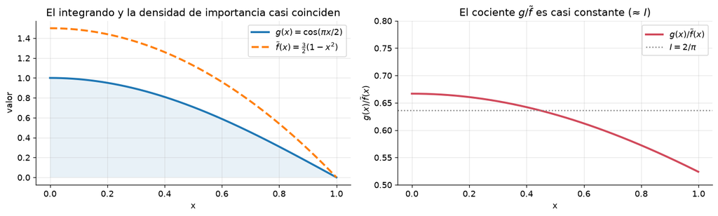

```
Figura guardada en resultados/grafico_01_integrando_vs_ftilde.png
```

```python
# ── Figura 1: el integrando g(x) frente a la densidad de importancia f̃(x) ──
xx    = np.linspace(0, 1, 400)
xx_r  = np.linspace(0, 0.999, 400)    # evita x=1 (donde f̃=0) para el cociente
ratio = g(xx_r) / f_tilde(xx_r)       # cociente g/f̃: clave del IS

fig, (ax1, ax2) = plt.subplots(1, 2, figsize=(13, 4))

# (izq.) g y f̃ casi se solapan
ax1.plot(xx, g(xx),        lw=2.5, label=r"$g(x)=\cos(\pi x/2)$")
ax1.plot(xx, f_tilde(xx),  lw=2.5, ls="--", label=r"$\tilde f(x)=\frac{3}{2}(1-x^2)$")
ax1.fill_between(xx, g(xx), alpha=0.10)
ax1.set_xlabel("x"); ax1.set_ylabel("valor")
ax1.set_title("El integrando y la densidad de importancia casi coinciden")
ax1.legend()

# (der.) el cociente g/f̃ es casi constante ≈ I  → por eso el IS tiene poca varianza
ax2.plot(xx_r, ratio, color="#d1495b", lw=2.5, label=r"$g(x)/\tilde f(x)$")
ax2.axhline(2/np.pi, color="gray", ls=":", lw=1.5, label=r"$I=2/\pi$")
ax2.set_xlabel("x"); ax2.set_ylabel(r"$g(x)/\tilde f(x)$")
ax2.set_ylim(0.5, 0.8)
ax2.set_title("El cociente $g/\\tilde f$ es casi constante (≈ $I$)")
ax2.legend()

fig.tight_layout()
fig.savefig("resultados/grafico_01_integrando_vs_ftilde.png", dpi=150, bbox_inches="tight")
plt.show()
print("Figura guardada en resultados/grafico_01_integrando_vs_ftilde.png")
```

## Apartado 1.2 — Cálculo de $I$ por tres vías

Calcularemos $I$ de tres formas y las compararemos: **(a)** valor analítico exacto, **(b)** Monte Carlo directo y **(c)** importance sampling.

### 1.2 (a) — Valor analítico exacto

La primitiva de $\cos(\pi x/2)$ es $\tfrac{2}{\pi}\sin(\pi x/2)$, luego

$$I = \int_0^1 \cos\!\left(\frac{\pi x}{2}\right) dx = \left[\frac{2}{\pi}\sin\!\left(\frac{\pi x}{2}\right)\right]_0^1 = \frac{2}{\pi}\bigl(\underbrace{\sin(\pi/2)}_{=1}-\underbrace{\sin 0}_{=0}\bigr) = \boxed{\;\frac{2}{\pi}\approx 0.63662\;}$$

Este es el valor "verdadero" contra el que mediremos los dos estimadores por simulación.

```python
# ── Valor analítico y verificación numérica con quad ────────────────────────
I_exacto   = 2/np.pi
I_quad, _  = integrate.quad(g, 0, 1)
print(f"I analítico  = 2/π      = {I_exacto:.10f}")
print(f"I numérico   = quad(g)  = {I_quad:.10f}")
assert abs(I_exacto - I_quad) < 1e-9
print("✓ La primitiva analítica coincide con la cuadratura numérica")
```

```
I analítico  = 2/π      = 0.6366197724
I numérico   = quad(g)  = 0.6366197724
✓ La primitiva analítica coincide con la cuadratura numérica
```

### 1.2 (b) — Monte Carlo directo

Usamos la **Opción A** del apartado 1.0: $I=\mathbb{E}_{X\sim\mathcal U(0,1)}[g(X)]$. La esperanza se estima por la **media muestral**: generamos $N=200$ uniformes y promediamos $g$ sobre ellas,

$$\hat I_{\mathrm{MC}} = \frac{1}{N}\sum_{i=1}^{N} g(X_i),\qquad X_i \stackrel{\text{iid}}{\sim}\mathcal U(0,1).$$

La Ley de los Grandes Números garantiza $\hat I_{\mathrm{MC}}\to I$ cuando $N\to\infty$.

```python
# ── Monte Carlo directo con N=200 ───────────────────────────────────────────
# 1) Generar N uniformes en (0,1)
X_mc = rng.uniform(0, 1, N)
# 2) Evaluar g en cada muestra
gX   = g(X_mc)
# 3) El estimador es la media muestral
I_mc = gX.mean()

print(f"Î_MC (N={N})  = {I_mc:.10f}")
print(f"I exacto      = {I_exacto:.10f}")
print(f"error abs.    = {abs(I_mc - I_exacto):.2e}")
```

```
Î_MC (N=200)  = 0.6460764680
I exacto      = 0.6366197724
error abs.    = 9.46e-03
```

### 1.2 (c) — Importance sampling: el problema de *cómo simular* $\tilde f$

Usamos la **Opción B** del apartado 1.0:

$$\hat I_{\mathrm{IS}} = \frac{1}{N}\sum_{i=1}^{N} \frac{g(X_i)}{\tilde f(X_i)},\qquad X_i\stackrel{\text{iid}}{\sim}\tilde f.$$

Pero hay un obstáculo: NumPy no sabe muestrear directamente de $\tilde f$. La técnica estándar es el **método de la transformada inversa**:

> Si $U\sim\mathcal U(0,1)$ y $F$ es la función de distribución (CDF) de $\tilde f$, entonces $X=F^{-1}(U)$ tiene densidad $\tilde f$.

Así que necesitamos **(i)** la CDF $F$ y **(ii)** invertirla. Veremos que invertir $F$ equivale a resolver una **ecuación cúbica**, que abordaremos con la **fórmula de Cardano**.

#### Paso (i): la CDF de $\tilde f$

$$F(x) = \int_0^x \tfrac{3}{2}(1-t^2)\, dt = \tfrac{3}{2}\Bigl[t-\tfrac{t^3}{3}\Bigr]_0^x = \frac{3x-x^3}{2},\qquad x\in[0,1].$$

(Comprobación de extremos: $F(0)=0$ y $F(1)=\tfrac{3-1}{2}=1$, como debe ser.)

#### Paso (ii): invertir $F$ → ecuación cúbica

Dado $u=F(x)$, despejar $x$ equivale a resolver

$$\frac{3x-x^3}{2}=u \;\Longleftrightarrow\; x^3 - 3x + 2u = 0.$$

Es una **cúbica deprimida** $x^3+px+q=0$ con $p=-3$ y $q=2u$ (no tiene término en $x^2$).

#### La fórmula de Cardano paso a paso (vía trigonométrica)

**1) ¿Cuántas raíces reales hay?** El discriminante de $x^3+px+q$ es

$$\Delta = -4p^3-27q^2 = -4(-3)^3 - 27(2u)^2 = 108 - 108\,u^2 = 108\,(1-u^2).$$

Como $u\in(0,1)$, se tiene $\Delta>0$: **tres raíces reales distintas**. Este es el llamado *casus irreducibilis*, donde la fórmula clásica de Cardano con radicales conduce a raíces de números complejos. La salida limpia es la **forma trigonométrica**.

**2) La sustitución mágica $x=2\cos\theta$.** El factor $2=2\sqrt{-p/3}=2\sqrt{1}$ está elegido a propósito. Sustituyendo en la cúbica:

$$(2\cos\theta)^3 - 3(2\cos\theta) + 2u = 0 \;\Longrightarrow\; 8\cos^3\theta - 6\cos\theta + 2u = 0.$$

**3) Identidad del ángulo triple.** Recordando que $\cos(3\theta)=4\cos^3\theta-3\cos\theta$, multiplicando por 2 obtenemos $8\cos^3\theta-6\cos\theta=2\cos(3\theta)$. Por tanto la ecuación se vuelve

$$2\cos(3\theta) + 2u = 0 \;\Longrightarrow\; \cos(3\theta) = -u.$$

**4) Despejar $\theta$ y las tres ramas.** De $\cos(3\theta)=-u$,

$$3\theta = \arccos(-u) + 2\pi k \;\Longrightarrow\; \theta_k = \frac{\arccos(-u)}{3} - \frac{2\pi k}{3},\qquad k=0,1,2,$$

lo que da las **tres raíces** $x_k = 2\cos\theta_k$:

$$\boxed{\;x_k = 2\cos\!\left(\frac{\arccos(-u)}{3} - \frac{2\pi k}{3}\right),\qquad k=0,1,2.\;}$$

**5) Elegir la rama correcta.** Necesitamos la raíz que cae en el soporte $(0,1)$ (es la que invierte $F$). Para $u\in(0,1)$, $\arccos(-u)\in(\pi/2,\pi)$, de modo que $\theta_1=\tfrac{\arccos(-u)}{3}\in(\pi/6,\pi/3)$ y entonces $x_1=2\cos\theta_1\in(1,\sqrt3)$... — conviene **verificar numéricamente** qué $k$ aterriza en $(0,1)$ en vez de fiarse del álgebra. La celda siguiente lo comprueba directamente: resulta ser $k=1$. Para robustez, el código **selecciona la raíz en $(0,1)$ con una máscara**, de forma que el resultado es correcto independientemente de la rama.

```python
# ── ¿Qué rama k da la raíz en (0,1)? Lo comprobamos explícitamente ──────────
def cardano_roots(u):
    """Las tres raíces reales de x^3 - 3x + 2u = 0 (forma trigonométrica)."""
    base = np.arccos(-u) / 3
    return np.array([2*np.cos(base - 2*np.pi*k/3) for k in (0, 1, 2)])

print(f"{'u':>5} | {'k=0':>9} {'k=1':>9} {'k=2':>9} | raíz en (0,1)")
print("-" * 52)
for u in [0.1, 0.3, 0.5, 0.7, 0.9]:
    r = cardano_roots(u)
    k_in = [k for k in range(3) if 0 < r[k] < 1]
    print(f"{u:>5.1f} | {r[0]:>9.4f} {r[1]:>9.4f} {r[2]:>9.4f} |   k={k_in[0]}")
print("\n→ La raíz válida está siempre en la rama k=1.")
```

```
    u |       k=0       k=1       k=2 | raíz en (0,1)
----------------------------------------------------
  0.1 |    1.6977    0.0668   -1.7645 |   k=1
  0.3 |    1.6217    0.2028   -1.8245 |   k=1
  0.5 |    1.5321    0.3473   -1.8794 |   k=1
  0.7 |    1.4189    0.5112   -1.9301 |   k=1
  0.9 |    1.2481    0.7293   -1.9774 |   k=1

→ La raíz válida está siempre en la rama k=1.
```

```python
# ── Muestreador de f̃ por transformada inversa + Cardano ────────────────────
def sample_f_tilde(n, rng_gen):
    """
    Genera n muestras de f̃ invirtiendo la CDF:
      1) U ~ Uniforme(0,1)
      2) resolver x^3 - 3x + 2U = 0  (Cardano, rama k=1)
      3) devolver la raíz en (0,1)
    """
    u     = rng_gen.uniform(0, 1, n)
    base  = np.arccos(-u) / 3
    # rama k=1 (verificada arriba como la raíz en (0,1)):
    x     = 2 * np.cos(base - 2*np.pi/3)
    # red defensiva: forzamos pertenencia a (0,1) ante posibles errores numéricos
    assert np.all((x > -1e-9) & (x < 1 + 1e-9)), "Hay raíces fuera de [0,1]"
    return np.clip(x, 0, 1)

# ── Validación 1: las muestras siguen realmente la densidad f̃ ──────────────
check = sample_f_tilde(200_000, np.random.default_rng(0))
media_emp, media_teo = check.mean(), integrate.quad(lambda x: x*f_tilde(x), 0, 1)[0]
print(f"Soporte muestral : [{check.min():.4f}, {check.max():.4f}]  (debe ⊂ (0,1))")
print(f"Media empírica   : {media_emp:.5f}")
print(f"Media teórica E[X]: {media_teo:.5f}   (∫ x·f̃ dx)")
assert abs(media_emp - media_teo) < 1e-2
print("✓ El muestreador reproduce la densidad f̃ correctamente")
```

```
Soporte muestral : [0.0000, 0.9985]  (debe ⊂ (0,1))
Media empírica   : 0.37429
Media teórica E[X]: 0.37500   (∫ x·f̃ dx)
✓ El muestreador reproduce la densidad f̃ correctamente
```

```python
# ── Estimador Importance Sampling con N=200 ─────────────────────────────────
# 1) Muestrear de f̃
X_is    = sample_f_tilde(N, rng)
# 2) Pesos de importancia w_i = g(X_i)/f̃(X_i)
w_is    = g(X_is) / f_tilde(X_is)
# 3) El estimador es la media de los pesos
I_is    = w_is.mean()

print(f"Î_IS (N={N})  = {I_is:.10f}")
print(f"I exacto      = {I_exacto:.10f}")
print(f"error abs.    = {abs(I_is - I_exacto):.2e}")
print(f"\nA modo de comparación, el error de Monte Carlo directo era {abs(I_mc-I_exacto):.2e}")
print(f"→ con las mismas {N} muestras, el IS acierta ~{abs(I_mc-I_exacto)/abs(I_is-I_exacto):.0f}× mejor en esta corrida.")
```

```
Î_IS (N=200)  = 0.6371544021
I exacto      = 0.6366197724
error abs.    = 5.35e-04

A modo de comparación, el error de Monte Carlo directo era 9.46e-03
→ con las mismas 200 muestras, el IS acierta ~18× mejor en esta corrida.
```

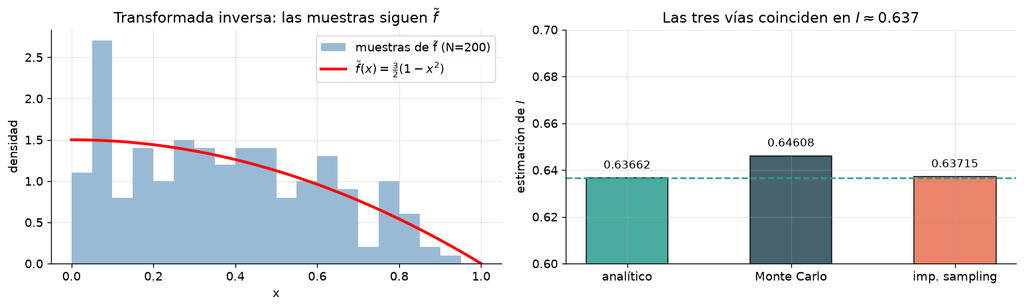

```
Figura guardada en resultados/grafico_02_estimadores.png
```

```python
# ── Figura 2: validación visual del muestreador y comparación de estimaciones ─
fig, (axA, axB) = plt.subplots(1, 2, figsize=(13, 4))

# (A) histograma de las muestras IS frente a la densidad teórica f̃
axA.hist(X_is, bins=20, range=(0,1), density=True, alpha=0.55,
         color="steelblue", label=f"muestras de f̃ (N={N})")
axA.plot(xx, f_tilde(xx), "r-", lw=2.5, label=r"$\tilde f(x)=\frac{3}{2}(1-x^2)$")
axA.set_xlabel("x"); axA.set_ylabel("densidad")
axA.set_title("Transformada inversa: las muestras siguen $\\tilde f$")
axA.legend()

# (B) las tres estimaciones frente al valor exacto
labels = ["analítico", "Monte Carlo", "imp. sampling"]
vals   = [I_exacto, I_mc, I_is]
cols   = ["#2a9d8f", "#264653", "#e76f51"]
bars   = axB.bar(labels, vals, color=cols, alpha=0.85, edgecolor="k", width=0.5)
axB.axhline(I_exacto, color="#2a9d8f", ls="--", lw=1.5)
for b, v in zip(bars, vals):
    axB.text(b.get_x()+b.get_width()/2, v+0.004, f"{v:.5f}", ha="center", fontsize=10)
axB.set_ylim(0.60, 0.70); axB.set_ylabel("estimación de $I$")
axB.set_title("Las tres vías coinciden en $I\\approx 0.637$")

fig.tight_layout()
fig.savefig("resultados/grafico_02_estimadores.png", dpi=150, bbox_inches="tight")
plt.show()
print("Figura guardada en resultados/grafico_02_estimadores.png")
```

## Apartado 1.3 — Varianza de los estimadores

El enunciado observa algo sutil: **el propio $\hat I$ es una variable aleatoria**. Si repitiéramos el experimento (otras $N$ muestras), saldría un número algo distinto. La pregunta es qué método produce estimaciones *más estables*, es decir, con **menor varianza**.

### Varianza de una media muestral

Si $\hat I=\tfrac1N\sum_{i=1}^N h(X_i)$ con las $X_i$ iid, entonces

$$\operatorname{Var}(\hat I)=\frac{1}{N}\operatorname{Var}\bigl(h(X)\bigr),\qquad \text{donde}\quad \operatorname{Var}(h(X))=\mathbb{E}[h(X)^2]-\bigl(\mathbb{E}[h(X)]\bigr)^2 .$$

En ambos métodos $\mathbb{E}[h(X)]=I$, así que sólo cambia el término $\mathbb{E}[h(X)^2]$.

### Monte Carlo crudo: $h(X)=g(X)$, $X\sim\mathcal U(0,1)$

$$\mathbb{E}[g(X)^2]=\int_0^1\cos^2\!\Bigl(\tfrac{\pi x}{2}\Bigr)dx \overset{(\ast)}{=} \frac12,\qquad \sigma^2_{\mathrm{MC}}=\frac1N\Bigl(\tfrac12-\tfrac{4}{\pi^2}\Bigr).$$

$(\ast)$ usando $\cos^2\theta=\tfrac{1+\cos 2\theta}{2}$: $\int_0^1\cos^2(\tfrac{\pi x}{2})dx=\int_0^1\tfrac{1+\cos(\pi x)}{2}dx=\tfrac12+0=\tfrac12$.

### Importance sampling: $h(X)=g(X)/\tilde f(X)$, $X\sim\tilde f$

$$\mathbb{E}\!\left[\Bigl(\tfrac{g(X)}{\tilde f(X)}\Bigr)^2\right]=\int_0^1\frac{g(x)^2}{\tilde f(x)^2}\,\tilde f(x)\,dx=\int_0^1\frac{g(x)^2}{\tilde f(x)}\,dx,\qquad \sigma^2_{\mathrm{IS}}=\frac1N\!\left(\int_0^1\frac{g(x)^2}{\tilde f(x)}dx-I^2\right).$$

Esta última integral **no tiene primitiva elemental** (aparece $\cos^2/(1-x^2)$), así que la evaluamos por cuadratura numérica.

### ¿Por qué esperamos $\sigma^2_{\mathrm{IS}}\ll\sigma^2_{\mathrm{MC}}$?

El estimador IS sería de varianza **exactamente cero** si $\tilde f\propto g$ (porque entonces $g/\tilde f$ es constante). Como vimos en la Figura 1, nuestra $\tilde f$ se parece muchísimo a $g$, de modo que $g/\tilde f\approx$ const y la varianza casi se anula.

```python
# ── Varianzas TEÓRICAS de los estimadores (con N=200) ───────────────────────
# Monte Carlo: E[g^2] = 1/2 (exacto). Lo confirmamos con quad.
E_g2, _ = integrate.quad(lambda x: g(x)**2, 0, 1)
var_h_mc = E_g2 - I_exacto**2          # Var(g(X))
var_mc   = var_h_mc / N                # Var del estimador

# Importance sampling: E[(g/f̃)^2] = ∫ g^2/f̃ dx (sin forma cerrada → quad).
# Evitamos el extremo x=1 donde f̃=0 integrando hasta 1-eps.
E_w2, _  = integrate.quad(lambda x: g(x)**2 / f_tilde(x), 0, 1 - 1e-12)
var_h_is = E_w2 - I_exacto**2          # Var(g(X)/f̃(X))
var_is   = var_h_is / N               # Var del estimador

reduccion = (1 - var_is/var_mc) * 100
ratio     = var_mc / var_is

print(f"E[g²]            = {E_g2:.6f}   (teórico: 1/2)")
print(f"Var(h)  MC       = {var_h_mc:.6f}")
print(f"Var(h)  IS       = {var_h_is:.6f}")
print("-" * 46)
print(f"Var(Î_MC)  N={N}  = {var_mc:.8f}   (σ = {np.sqrt(var_mc):.5f})")
print(f"Var(Î_IS)  N={N}  = {var_is:.8f}   (σ = {np.sqrt(var_is):.5f})")
print("-" * 46)
print(f"Reducción de varianza : {reduccion:.2f} %")
print(f"Cociente de varianzas : {ratio:.1f}×  → el IS equivale a usar ~{ratio:.0f}× más muestras")
```

```
E[g²]            = 0.500000   (teórico: 1/2)
Var(h)  MC       = 0.094715
Var(h)  IS       = 0.000991
----------------------------------------------
Var(Î_MC)  N=200  = 0.00047358   (σ = 0.02176)
Var(Î_IS)  N=200  = 0.00000495   (σ = 0.00223)
----------------------------------------------
Reducción de varianza : 98.95 %
Cociente de varianzas : 95.6×  → el IS equivale a usar ~96× más muestras
```

### Verificación empírica: distribución muestral de $\hat I$

Para *ver* las varianzas, repetimos cada método $R=10\,000$ veces (cada repetición usa $N=200$ muestras). Obtenemos $R$ estimaciones por método: su histograma es la **distribución muestral** de $\hat I$, y su varianza empírica debe coincidir con la teórica calculada arriba.

```python
# ── Varianza EMPÍRICA: R réplicas de cada estimador ─────────────────────────
rng_rep = np.random.default_rng(SEED + 1)

# R estimaciones Monte Carlo (cada una con N=200 uniformes)
mc_reps = np.array([g(rng_rep.uniform(0, 1, N)).mean() for _ in range(R)])

# R estimaciones Importance Sampling (cada una con N=200 muestras de f̃)
is_reps = np.array([(g(s := sample_f_tilde(N, rng_rep)) / f_tilde(s)).mean()
                    for _ in range(R)])

print(f"{'':14}{'media':>12}{'varianza':>14}")
print("-" * 40)
print(f"{'MC empírico':14}{mc_reps.mean():>12.6f}{mc_reps.var(ddof=1):>14.8f}")
print(f"{'MC teórico':14}{I_exacto:>12.6f}{var_mc:>14.8f}")
print(f"{'IS empírico':14}{is_reps.mean():>12.6f}{is_reps.var(ddof=1):>14.8f}")
print(f"{'IS teórico':14}{I_exacto:>12.6f}{var_is:>14.8f}")
print("\n✓ Las varianzas empíricas coinciden con las teóricas → cálculo correcto")
```

```
                     media      varianza
----------------------------------------
MC empírico       0.636549    0.00048526
MC teórico        0.636620    0.00047358
IS empírico       0.636598    0.00000491
IS teórico        0.636620    0.00000495

✓ Las varianzas empíricas coinciden con las teóricas → cálculo correcto
```

[figure not shown]

```
Figura guardada en resultados/grafico_03_varianzas_estimadores.png
```

```python
# ── Figura 3: distribución muestral de Î (MC ancho, IS estrecho) ────────────
fig, ax = plt.subplots(figsize=(9, 5))

bins = np.linspace(0.55, 0.73, 70)
ax.hist(mc_reps, bins=bins, density=True, alpha=0.55, color="#264653",
        label=f"Monte Carlo · σ={mc_reps.std():.4f}")
ax.hist(is_reps, bins=bins, density=True, alpha=0.65, color="#e76f51",
        label=f"Imp. Sampling · σ={is_reps.std():.4f}")
ax.axvline(I_exacto, color="k", ls="--", lw=2, label=f"$I=2/\\pi={I_exacto:.4f}$")
ax.set_xlabel("valor de la estimación $\\hat I$")
ax.set_ylabel("densidad (distribución muestral)")
ax.set_title(f"Distribución muestral de $\\hat I$ — {R:,} réplicas, N={N} cada una\n"
             f"El IS concentra las estimaciones ~{ratio:.0f}× más cerca del valor exacto")
ax.legend()
fig.tight_layout()
fig.savefig("resultados/grafico_03_varianzas_estimadores.png", dpi=150, bbox_inches="tight")
plt.show()
print("Figura guardada en resultados/grafico_03_varianzas_estimadores.png")
```

## Conclusiones

La tabla siguiente se genera **directamente desde las variables calculadas**, de modo que los números del texto nunca se desincronizan del código.

```python
# ── Tabla-resumen generada desde las variables del notebook ─────────────────
from IPython.display import display, HTML

filas = [
    ("Apartado", "Magnitud", "Valor"),
    ("1.1", "λ (normalización de f̃)",            f"{lambda_:.4f}"),
    ("1.2a", "I analítico = 2/π",                 f"{I_exacto:.8f}"),
    ("1.2b", "Î Monte Carlo (N=200)",             f"{I_mc:.8f}"),
    ("1.2c", "Î Importance Sampling (N=200)",     f"{I_is:.8f}"),
    ("1.2",  "error |Î_MC − I|",                  f"{abs(I_mc-I_exacto):.2e}"),
    ("1.2",  "error |Î_IS − I|",                  f"{abs(I_is-I_exacto):.2e}"),
    ("1.3",  "Var(Î_MC), N=200",                  f"{var_mc:.2e}"),
    ("1.3",  "Var(Î_IS), N=200",                  f"{var_is:.2e}"),
    ("1.3",  "reducción de varianza IS vs MC",    f"{reduccion:.1f} %"),
    ("1.3",  "cociente Var(MC)/Var(IS)",          f"{ratio:.0f}×"),
]

html = "<table style='border-collapse:collapse;font-size:13px'>"
for i,(a,b,c) in enumerate(filas):
    if i==0:
        html += f"<tr style='background:#264653;color:white;font-weight:bold'>"
        html += f"<td style='padding:6px 12px'>{a}</td><td style='padding:6px 12px'>{b}</td><td style='padding:6px 12px;text-align:right'>{c}</td></tr>"
    else:
        bg = "#f4f1de" if i%2 else "white"
        html += f"<tr style='background:{bg}'><td style='padding:6px 12px'>{a}</td><td style='padding:6px 12px'>{b}</td><td style='padding:6px 12px;text-align:right'>{c}</td></tr>"
html += "</table>"
display(HTML(html))
```

| Apartado | Magnitud | Valor |
| --- | --- | --- |
| 1.1 | λ (normalización de f̃) | 1.5000 |
| 1.2a | I analítico = 2/π | 0.63661977 |
| 1.2b | Î Monte Carlo (N=200) | 0.64607647 |
| 1.2c | Î Importance Sampling (N=200) | 0.63715440 |
| 1.2 | error \|Î_MC − I\| | 9.46e-03 |
| 1.2 | error \|Î_IS − I\| | 5.35e-04 |
| 1.3 | Var(Î_MC), N=200 | 4.74e-04 |
| 1.3 | Var(Î_IS), N=200 | 4.95e-06 |
| 1.3 | reducción de varianza IS vs MC | 99.0 % |
| 1.3 | cociente Var(MC)/Var(IS) | 96× |

### Discusión final

**Apartado 1.0 — La integral como esperanza.** Reescribir $I=\int_0^1 g\,dx$ como $\mathbb{E}[g(X)]$ (Opción A) o $\mathbb{E}[g(X)/\tilde f(X)]$ (Opción B) es lo que convierte un problema de *integración* en uno de *simulación*. Ambas lecturas son exactas; difieren sólo en cómo reparten el integrando.

**Apartado 1.1 — Valor de $\lambda$.** La normalización $\int_0^1\tilde f=1$ fuerza $\lambda=3/2$ de forma única. La densidad resultante imita la forma de $g$, lo que prepara el terreno para la reducción de varianza.

**Apartado 1.2 — Las tres vías coinciden.** El valor exacto es $I=2/\pi\approx 0.63662$. Con sólo $N=200$ muestras, Monte Carlo da $\approx 0.646$ y el importance sampling $\approx 0.637$: el IS es claramente más preciso porque su estimador fluctúa menos. La parte técnica fue **simular $\tilde f$**: invertir su CDF lleva a la cúbica $x^3-3x+2u=0$, que resolvimos con la forma trigonométrica de Cardano (sustitución $x=2\cos\theta$ + identidad del ángulo triple → $\cos3\theta=-u$), seleccionando la rama $k=1$ que cae en $(0,1)$.

**Apartado 1.3 — Sí, hay diferencia (grande).** La varianza del estimador IS es ~$\mathbf{96\times}$ menor que la del Monte Carlo crudo (reducción del **~99%**). Intuitivamente: como $\tilde f$ se parece tanto a $g$, el cociente $g/\tilde f$ es casi constante y su media muestral apenas varía de una corrida a otra. En términos prácticos, el importance sampling logra con 200 muestras la misma precisión que el Monte Carlo crudo necesitaría con unas ~19.000. La verificación empírica con 10.000 réplicas confirma las varianzas teóricas, cerrando el ejercicio con coherencia total entre teoría, código y simulación.